# Projet de Machine Learning : Prédiction du Leaderboard du jeu PUBG

### *BLANCHARD ELEONORE, LY YANNICK*

[figure not shown]

## Introduction au projet et au jeu PUBG

**Objectif du projet** : Notre projet a pour objectif de prédire le classement de fin de match de tous les joueurs pour une partie donnée pour le jeu PUBG (PlayerUnknown's Battlegrounds). La variable à expliquer (classement de fin de match) est exprimée en percentiles, ce qui signifie qu'elle prend des valeurs entre 0 et 1 ; 1 signifiant que le joueur est arrivé premier, et 0 signifiant qu'il est dernier.

**Principe du jeu** : 100 joueurs sont lancés dans une partie et leur objectif est d'être le dernier survivant de la partie (jeu de type battle royal). Dans PUBG, plusieurs modes sont possibles : solo, duo ou squad (équipe de 5). A chaque début de partie, les joueurs choisissent où ils sont parachutés, et ne disposent d'aucun accessoire ni d'arme. Ils pourront ramasser des armes, des grenades, bandages, etc. et trouver des véhicules au cours de la partie. Au bout de quelques minutes de jeu, la zone jouable de la partie commence à se rétrécir vers un emplacement aléatoire (zone de sécurité). Tout joueur en dehors de la zone de sécurité subit des dégats incrémentaux et finalement éliminés s'ils ne la rejoignent pas à temps. Il en résulte une carte plus réduite qui augmente la chance de rencontrer un ennemi.

**Données** : Nous avons récupéré les statistiques de joueurs sur 47.964 parties. Elles sont composées de 26 features décrites plus bas. Ainsi, dans la base de données, chaque ligne représente les statistiques d'un joueur dans une partie donnée quelque soit son mode (solo, duo ou squad).

**Philosophie du projet** : L'objectif est d'analyser les données de ces matchs afin de comprendre les statistiques importantes menant à la victoire d'un joueur, dans le but de prédire le classement final de parties futures. Notre analyse prend en compte le fait de jouer en solo, duo ou squad.

**Limites** : Etant donné que les données sont celles de fin de partie, l'objectif de notre prédiction n'est pas très utile car le classement est déjà disponible en fin de partie. En revanche, notre projet s'inscrit dans une volonté de développer un système permettant de prédire en direct la probabilité de gagner d'un joueur ; basé sur des données reçues en temps réel qui seraient renvoyées dans notre modèle (utilisation dans une compétition pour les spectateurs).

```python
import pandas as pd
import matplotlib.pyplot as plt
import numpy as np
import seaborn as sns
from sklearn.model_selection import train_test_split, GridSearchCV
from sklearn import preprocessing, tree, metrics
from sklearn.ensemble import RandomForestRegressor
import lightgbm as lgb
```

## Données

```python
data = pd.read_csv('Data.csv')
```

```python
data.info()
```

```
<class 'pandas.core.frame.DataFrame'>
RangeIndex: 4446966 entries, 0 to 4446965
Data columns (total 29 columns):
Id                 object
groupId            object
matchId            object
assists            int64
boosts             int64
damageDealt        float64
DBNOs              int64
headshotKills      int64
heals              int64
killPlace          int64
killPoints         int64
kills              int64
killStreaks        int64
longestKill        float64
matchDuration      int64
matchType          object
maxPlace           int64
numGroups          int64
rankPoints         int64
revives            int64
rideDistance       float64
roadKills          int64
swimDistance       float64
teamKills          int64
vehicleDestroys    int64
walkDistance       float64
weaponsAcquired    int64
winPoints          int64
winPlacePerc       float64
dtypes: float64(6), int64(19), object(4)
memory usage: 983.9+ MB
```

- `Id` : Id permettant d'identifier un joueur.
- `groupId` : Id permettant d'identifier un groupe.
- `matchId`: Id permettant d'identifier un match.
- `assists`: Nombre d'ennemis touchés par ce joueur et qui ont été tués par la suite par un membre de son équipe.
- `boosts`: Nombre de boosts utilisés (type dopage pour courir plus vite et se regénérer plus vite).
- `damageDealt`: Nombre total de dommages causés aux ennemis.
- `DBNOs`: Nombre de fois où le joueur a été mis au sol mais n'est pas mort (relevé par la suite par un membre de son équipe).
- `headshotKills`: Nombre d'ennemis tués avec un tir à la tête.
- `heals`: Nombre de soins utilisés (type bandage et trousse de soin).
- `killPlace`: Classement du joueur dans le match par rapport au nombre d'ennemis tués.
- `killPoints`: Classement du joueur externe au match par rapport au nombre d'ennemis tués total.
- `kills`: Nombre d'ennemis tués.
- `killStreaks`: Nombre maximal d'ennemis maximal tués en un temps court.
- `longestKill`: Distance la plus longue entre le joueur et un ennemi tué au moment de sa mort.
- `matchDuration`: Durée du match en secondes.
- `matchType`: Type de match (Solo, Duo, Squad).
- `maxPlace`: Le pire classement.
- `numGroups`: Nombre de groupes
- `rankPoints`: Des points sont attribués au joueur en dehors du match pour définir leur rank (bronze, argent, or...)
- `revives`: Nombre de fois que le joueur a été relevé par un membre de son équipe.
- `rideDistance`: Distance totale parcourue dans des véhicules par le joueur (en mètres).
- `roadKills`: Nombre d'ennemis tués lorsque le joueur était dans un véhicule.
- `swimDistance`: Distance totale parcourue en nageant par le joueur (en mètres).
- `teamKills`: Nombre de fois que le joueur a été un membre de son équipe.
- `vehicleDestroys`: Nombre de véhicules détruits.
- `walkDistance`: Distance totale parcourue à pieds par le joueur(en mètres).
- `weaponsAcquired`: Nombre d'armes ramassés.
- `winPoints`: Classement du joueur externe au match par rapport au nombre total de victoires.
- `winPlacePerc`: Cible de la prédiction. C'est un percentile du classement, où 1 correspond à la première place et 0 à la dernière place du match.

## Analyse de l'échantillon

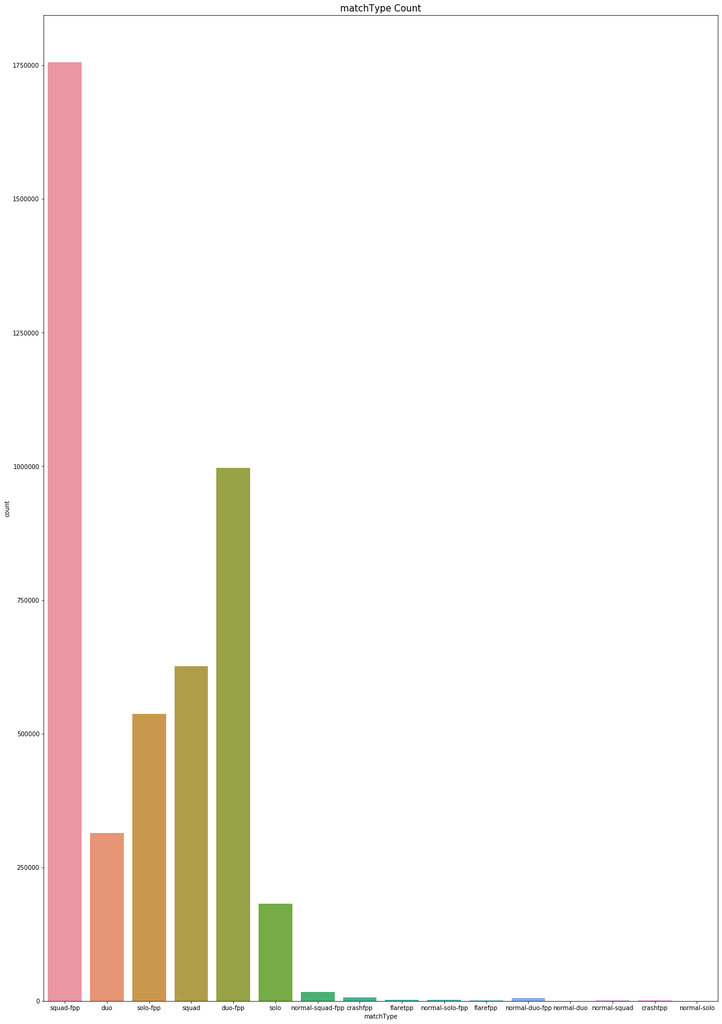

```python
plt.figure(figsize=(20,30))
sns.countplot(data['matchType'])
plt.title("matchType Count", fontsize=15)
plt.show()
```

Nous observons que parmi l'échantillon récupéré que la majorité des parties que nous allons analyser sont des parties en équipe (squad-fpp + squad). Cela n'est pas étonnant étant donné que c'est un jeu qui se joue énormément en équipe et avec des amis.

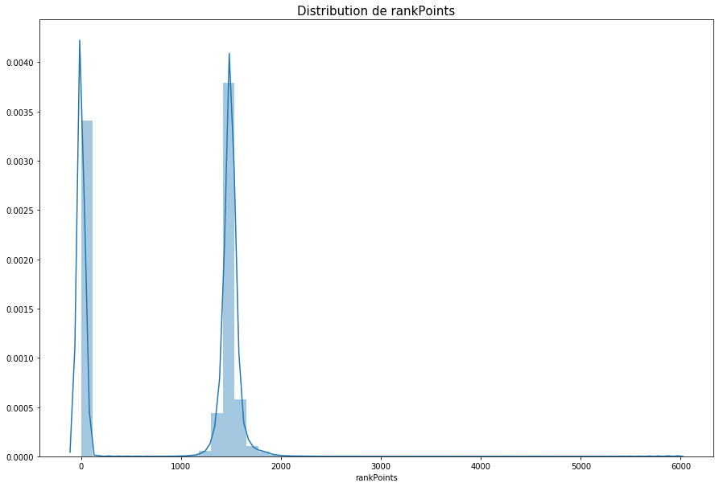

```python
plt.figure(figsize=(15,10))
plt.title("Distribution de rankPoints",fontsize=15)
sns.distplot(data['rankPoints'])
plt.show()
```

Il faut savoir que dans le jeu PUBG, un système de ranking appelé ELO est attribué à chaque joueur afin que le niveau des joueurs dans les parties soit homogène. Ce ranking varie selon la performance du joueur dans une partie. Ce système de ranking est réinitialisé toutes les saisons (deux mois). Il est nécessaire qu'un joueur effectue dix premières parties dites de classement afin de disposer d'un ELO. Ceci explique pourquoi dans le graphique nous observons autant de joueurs ayant un `rankPoints` nul. Parmi les joueurs classés, nous observons que la moyenne du `rankPoints` est autour de 1500, ce qui correspond à l'ELO d'un joueur moyen.

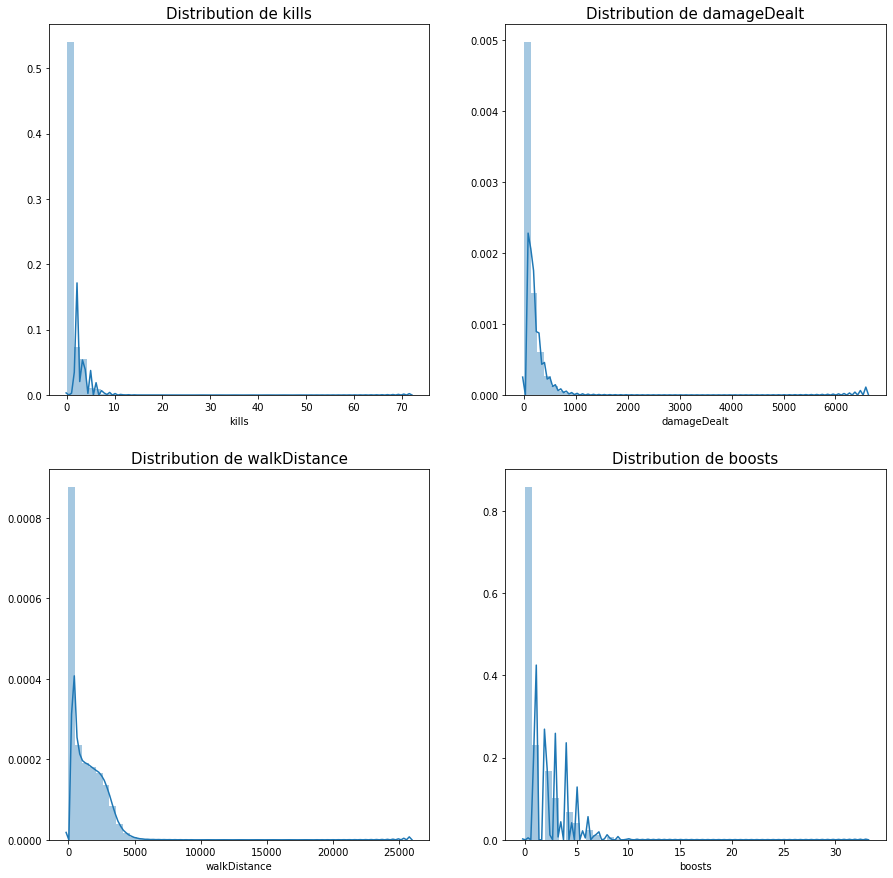

```python
plt.figure(figsize=(15,15))

plt.subplot(2,2,1)
plt.title("Distribution de kills",fontsize=15)
sns.distplot(data['kills'])

plt.subplot(2,2,2)
plt.title("Distribution de damageDealt",fontsize=15)
sns.distplot(data['damageDealt'])

plt.subplot(2,2,3)
plt.title("Distribution de walkDistance",fontsize=15)
sns.distplot(data['walkDistance'])

plt.subplot(2,2,4)
plt.title("Distribution de boosts",fontsize=15)
sns.distplot(data['boosts'])
plt.show()
```

On a représenté la distribution de plusieurs variables : `kills`, `damageDealt`, `walkDistance`, `boosts`. Nous observons qu'elles sont distribuées autour de 0 pour la majorité des joueurs. Cela s'explique par la fait qu'en début de partie, un tiers des joueurs sont tués sans qu'ils ne puissent faire quoi que ce soit.

Nous voyons également que certains joueurs ont des statistiques de jeux largement supérieurs à la moyenne (`kills` > 25, `damageDealt` > 3000...). Cela nous fait penser qu'il y a des tricheurs dans l'échantillon, que nous devrons traiter par la suite afin de ne pas biaiser le modèle.

## Data Engineering

Cette partie concerne le traitement des données, dont la gestion des données manquantes et la conversion des variables catégorielles en un format compris par les algorithmes de machine learning. Dans le cadre de la séparation des échantillons d'entrainement (`train`) et de test (`test`), nous avons du faire attention à ne séparer les données d'un même match dans deux échantillons différents.

```python
data.dropna(inplace = True)
(nrow, ncol) = data.shape
```

Dans PUBG, il y a plusieurs modes de jeu. Par exemple il est possible de jouer en mode solo fpp (first person player) ou tpp (third person player). Or cela ne change pas grand chose. Donc nous avons décidé de simplifier les types de matchs et d'enlever les parties spéciales (type évènements).

```python
data['matchType'].replace('solo-fpp', 'solo', inplace = True)
data['matchType'].replace('normal-solo', 'solo', inplace = True)
data['matchType'].replace('normal-solo-fpp', 'solo', inplace = True)
data['matchType'].replace('duo-fpp', 'duo', inplace = True)
data['matchType'].replace('normal-duo', 'duo', inplace = True)
data['matchType'].replace('normal-duo-fpp', 'duo', inplace = True)
data['matchType'].replace('squad-fpp', 'squad', inplace = True)
data['matchType'].replace('normal-squad', 'squad', inplace = True)
data['matchType'].replace('normal-squad-fpp', 'squad', inplace = True)
data = data[data.matchType != 'flarefpp']
data = data[data.matchType != 'flaretpp']
data = data[data.matchType != 'crashfpp']
data = data[data.matchType != 'crashtpp']
```

**LabelEncoding**

```python
le_1 = preprocessing.LabelEncoder()
le_matchType = le_1.fit_transform(data['matchType'])
le_2 = preprocessing.LabelEncoder()
le_groupId = le_2.fit_transform(data['groupId'])
le_3 = preprocessing.LabelEncoder()
le_matchId = le_3.fit_transform(data['matchId'])

data['matchType'] = le_matchType
data['groupId'] = le_groupId
data['matchId'] = le_matchId

print('Le code de matchType 0 correspond à un match en {}.'.format(le_1.inverse_transform([0])[0]))
print('Le code de matchType 1 correspond à un match en {}.'.format(le_1.inverse_transform([1])[0]))
print('Le code de matchType 2 correspond à un match en {}.'.format(le_1.inverse_transform([2])[0]))
```

```
Le code de matchType 0 correspond à un match en duo.
Le code de matchType 1 correspond à un match en solo.
Le code de matchType 2 correspond à un match en squad.
```

**Séparation des échantillons d'entrainement (**`train`**) et de test (**`test`**)**

Nous décidons de ne garder que 1000 matchs par soucis de puissance de calcul car nous comptons par la suite utiliser des algorithmes ensemblistes tels que le Random Forest et le LightGBM.

```python
data_matchId = data['matchId'].drop_duplicates()
data_matchId = data_matchId.sample(1000)
X_matchId_train, X_matchId_test = train_test_split(data_matchId, test_size = 0.33, random_state = 42)

train = data[data['matchId'].isin(X_matchId_train)]
test = data[data['matchId'].isin(X_matchId_test)]
X_train = train.drop(['Id', 'winPlacePerc'], axis = 1)
y_train = train['winPlacePerc']
X_test = test.drop(['Id', 'winPlacePerc'], axis = 1)
y_test = test['winPlacePerc']
```

## Baseline

Dans cette partie, nous avons voulu construire un modèle de référence (benchmark) rapide à lancer. Il nous permettra de nous guider afin de savoir si les changements apportés par la suite au modèle ou aux données améliorera notre prédiction. Comme baseline, nous avons construit un arbre de régression simple sans toucher aux hyperparamètres.

Comme score, nous avons hésité entre les MSE (mean squared error) et MAE (mean absolute error). Le premier pénalise les grosses erreurs tandis que le deuxième équipondère toutes les erreurs. Néanmoins, comme la variable explicative est comprise entre 0 et 1, le MSE a tendance à minimiser l'erreur. De plus, nous considérons qu'une erreur de classement est aussi importante quelque soit la place du joueur. C'est pour ces raisons que nous avons décidé de choisir le MAE comme score de comparaison.

**Arbre de régression**

```python
clf = tree.DecisionTreeRegressor(random_state = 42)
clf.fit(X_train, y_train)
```

```
DecisionTreeRegressor(criterion='mse', max_depth=None, max_features=None,
                      max_leaf_nodes=None, min_impurity_decrease=0.0,
                      min_impurity_split=None, min_samples_leaf=1,
                      min_samples_split=2, min_weight_fraction_leaf=0.0,
                      presort=False, random_state=42, splitter='best')
```

**Erreurs**

Nous calculons une erreur moyenne car nous testons le modèle sur tous les matchs de l'échantillon de test.

```python
sum_err_mse = 0
sum_err_mae = 0
count = 0
for i in X_test['matchId'].unique():
    y_predict = clf.predict(X_test[X_test['matchId'] == i])
    sum_err_mse += metrics.mean_squared_error(y_test[(X_test['matchId'] == i)], y_predict)
    sum_err_mae += metrics.mean_absolute_error(y_test[(X_test['matchId'] == i)], y_predict)
    count += 1

print('MSE : {}'.format(round(sum_err_mse/count,4)))
print('MAE : {}'.format(round(sum_err_mae/count,4)))
```

```
MSE : 0.02
MAE : 0.0942
```

On voit bien ici que le MSE sous-estime largement notre erreur. Le MAE est donc une meilleure métrique de risque pour notre sujet.

## Engineering Data Analysis

Dans cette partie, nous effectuons une analyse approfondie des données. Nous commencons par éliminer les tricheurs car ils biaisent notre modèle de prédiction. Puis nous comparons les features entre elles en terme d'importance et de corrélation avec la variable à expliquer afin de supprimer celles qui ne nous semblent pas pertinentes. Ensuite, nous créons de nouvelles features qui nous semblent appropriées afin d'améliorer le modèle.

**Elimination des tricheurs**

On observe dans tous les graphiques précédents qu'il y a beaucoup d'outliers, c'est-à-dire des valeurs extrêmes comparé à la moyenne des joueurs. Nous soupsonnons alors la présence de tricheurs parmi ces parties. Nous décidons d'effectuer un traitement afin d'essayer de les éliminer.

```python
print('Nombre de joueurs supprimés : {}'.format(len(X_train[(X_train['walkDistance']==0) & (X_train['kills']>1)])))
y_train = y_train.drop(X_train[(X_train['walkDistance']==0) & (X_train['kills']>1)].index)
X_train = X_train.drop(X_train[(X_train['walkDistance']==0) & (X_train['kills']>1)].index)
```

```
Nombre de joueurs supprimés : 3
```

*Suppression des joueurs ayant tué plus de 25 ennemis :*

```python
print('Nombre de joueurs supprimés : {}'.format(len(X_train[(X_train['kills']>25)])))
y_train = y_train.drop(X_train[(X_train['kills']>25)].index)
X_train = X_train.drop(X_train[(X_train['kills']>25)].index)
```

```
Nombre de joueurs supprimés : 1
```

*Suppression des joueurs ayant un taux de tir dans la tête supérieur à 80% pour un nombre d'ennemis tués supérieur à 5 :*

```python
print('Nombre de joueurs supprimés : {}'.format(len(X_train[(X_train['headshotKills']/X_train['kills']>0.8) & (X_train['kills']>5)])))
y_train = y_train.drop(X_train[(X_train['headshotKills']/X_train['kills']>0.8) & (X_train['kills']>5)].index)
X_train = X_train.drop(X_train[(X_train['headshotKills']/X_train['kills']>0.8) & (X_train['kills']>5)].index)
```

```
Nombre de joueurs supprimés : 16
```

*Suppression des joueurs ayant tués au moins 6 ennemis en peu de temps :*

```python
print('Nombre de joueurs supprimés : {}'.format(len(X_train[(X_train['killStreaks']>=6)])))
y_train = y_train.drop(X_train[(X_train['killStreaks']>=6)].index)
X_train = X_train.drop(X_train[(X_train['killStreaks']>=6)].index)
```

```
Nombre de joueurs supprimés : 2
```

*Suppression des joueurs ayant tué un ennemis à plus de 1000 mètres :*

```python
print('Nombre de joueurs supprimés : {}'.format(len(X_train[(X_train['longestKill']>1000)])))
y_train = y_train.drop(X_train[(X_train['longestKill']>1000)].index)
X_train = X_train.drop(X_train[(X_train['longestKill']>1000)].index)
```

```
Nombre de joueurs supprimés : 0
```

*Suppression des joueurs ayant parcouru plus de 10000 mètres à pied :*

```python
print('Nombre de joueurs supprimés : {}'.format(len(X_train[(X_train['walkDistance']>10000)])))
y_train = y_train.drop(X_train[(X_train['walkDistance']>10000)].index)
X_train = X_train.drop(X_train[(X_train['walkDistance']>10000)].index)
```

```
Nombre de joueurs supprimés : 4
```

*Suppression des joueurs ayant parcouru plus de 20000 mètres en véhicules, en supposant qu'on parcours deux fois plus de distance motorisé qu'à pieds:*

```python
print('Nombre de joueurs supprimés : {}'.format(len(X_train[(X_train['rideDistance']>20000)])))
y_train = y_train.drop(X_train[(X_train['rideDistance']>20000)].index)
X_train = X_train.drop(X_train[(X_train['rideDistance']>20000)].index)
```

```
Nombre de joueurs supprimés : 0
```

*Suppression des joueurs ayant nagé plus de 1500 mètres :*

```python
print('Nombre de joueurs supprimés : {}'.format(len(X_train[(X_train['swimDistance']>1500)])))
y_train = y_train.drop(X_train[(X_train['swimDistance']>1500)].index)
X_train = X_train.drop(X_train[(X_train['swimDistance']>1500)].index)
```

```
Nombre de joueurs supprimés : 0
```

*Suppression des joueurs ayant ramassé plus de 40 armes :*

```python
print('Nombre de joueurs supprimés : {}'.format(len(X_train[(X_train['weaponsAcquired']>40)])))
y_train = y_train.drop(X_train[(X_train['weaponsAcquired']>40)].index)
X_train = X_train.drop(X_train[(X_train['weaponsAcquired']>40)].index)
```

```
Nombre de joueurs supprimés : 0
```

*Suppression des joueurs ayant consommé plus de 20 boosts :*

```python
print('Nombre de joueurs supprimés : {}'.format(len(X_train[(X_train['boosts']>20)])))
y_train = y_train.drop(X_train[(X_train['boosts']>20)].index)
X_train = X_train.drop(X_train[(X_train['boosts']>20)].index)
```

```
Nombre de joueurs supprimés : 0
```

*Suppression des joueurs ayant consommé plus de 45 heals :*

```python
print('Nombre de joueurs supprimés : {}'.format(len(X_train[(X_train['heals']>45)])))
y_train = y_train.drop(X_train[(X_train['heals']>45)].index)
X_train = X_train.drop(X_train[(X_train['heals']>45)].index)
```

```
Nombre de joueurs supprimés : 0
```

**Features les plus importantes de la baseline**

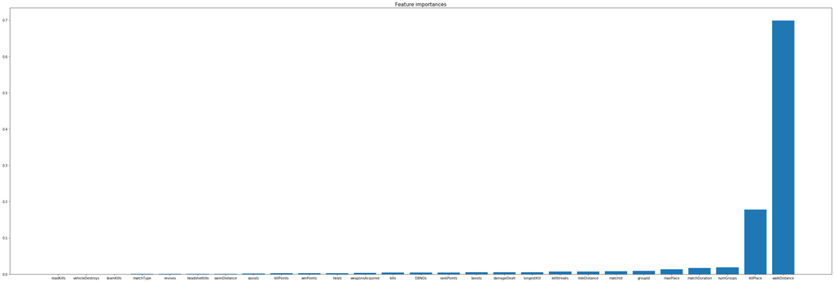

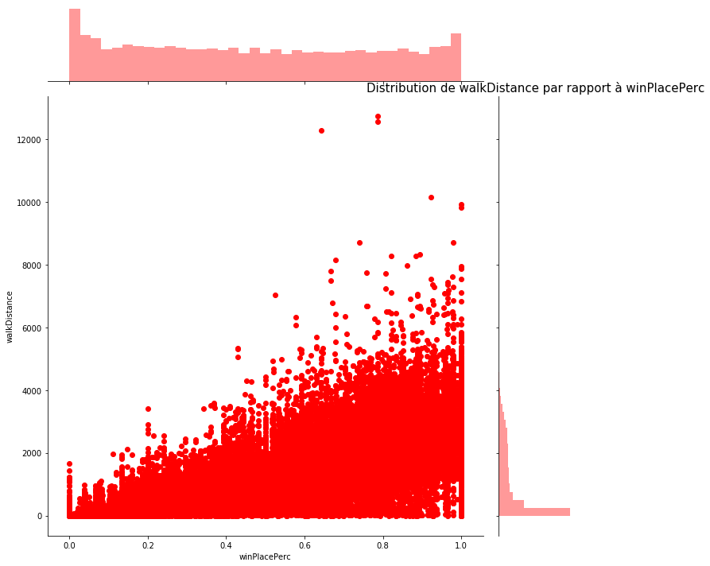

```python
labels = pd.DataFrame(X_test.columns)
feature_importances = pd.DataFrame(clf.feature_importances_)
df = pd.concat([labels, feature_importances], axis = 1)
df.columns = ['Features', 'Feature importances']
df.sort_values(by = ['Feature importances'], inplace = True)
plt.figure(figsize=(45,15))
plt.bar(df['Features'], df['Feature importances'])
plt.title('Feature importances', fontsize=15)
plt.show()

plt.figure(figsize=(45,15))
sns.jointplot("winPlacePerc", "walkDistance", data=train, height=10, ratio=5, color="r")
plt.title('Distribution de walkDistance par rapport à winPlacePerc', fontsize=15)
plt.show()
```

On a tracé le graphique des features les plus importantes de l'arbre de régression ainsi que la distribution de `winPlacePerc` par rapport à `walkDistance`.

On observe que la feature la plus importante est `walkDistance` (70%), et de loin. Or cette variable nous semble redondante avec la variable à expliquer car plus l'on survie longtemps dans la partie et plus la distance de marche sera élevée. On considère que la variable est trop explicative et biaise les résultats de notre prédiction. Donc nous décidons de l'enlever par la suite.

**Baseline sans `walkDistance` et sans tricheur**

```python
X_train = X_train.drop(['walkDistance'], axis = 1)
X_test = X_test.drop(['walkDistance'], axis = 1)
clf = tree.DecisionTreeRegressor(random_state = 42)
clf.fit(X_train, y_train)
sum_err_mae = 0
count = 0
for i in X_test['matchId'].unique():
    y_predict = clf.predict(X_test[X_test['matchId'] == i])
    sum_err_mae += metrics.mean_absolute_error(y_test[(X_test['matchId'] == i)], y_predict)
    count += 1

print('MAE : {}'.format(round(sum_err_mae/count, 4)))
```

```
MAE : 0.107
```

On voit que l'erreur a augmenté, ce qui est attendu.

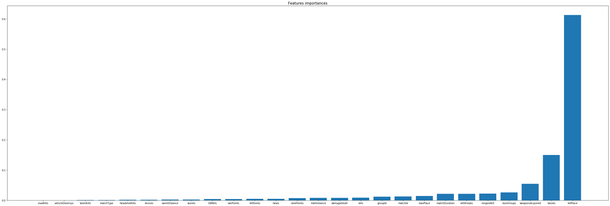

```python
labels = pd.DataFrame(X_test.columns)
feature_importances = pd.DataFrame(clf.feature_importances_)
df = pd.concat([labels, feature_importances], axis = 1)
df.columns = ['Features', 'Feature importances']
df.sort_values(by = ['Feature importances'], inplace = True)
plt.figure(figsize=(45,15))
plt.bar(df['Features'], df['Feature importances'])
plt.title('Features importances', fontsize=15)
plt.show()
```

En retirant la variable `walkDistance`, les features les plus importantes ne sont plus dans le même ordre que précédemment. Cela provient de la nature d'un arbre de régression, car il y a dépendance entre les noeuds des niveaux inférieurs et suppérieurs.

Par exemple, la variable `matchDuration` ne nous semble pas pertinente au premier abord. Or, elle ressort ici comme une des features les plus importantes. En effet, on peut imaginer que les features importantes ne sont pas les mêmes dans un match de 20 minutes ou 30 minutes, et que cette variable est choisie par le modèle sur un noeud supérieur.

**Matrice de corrélation**

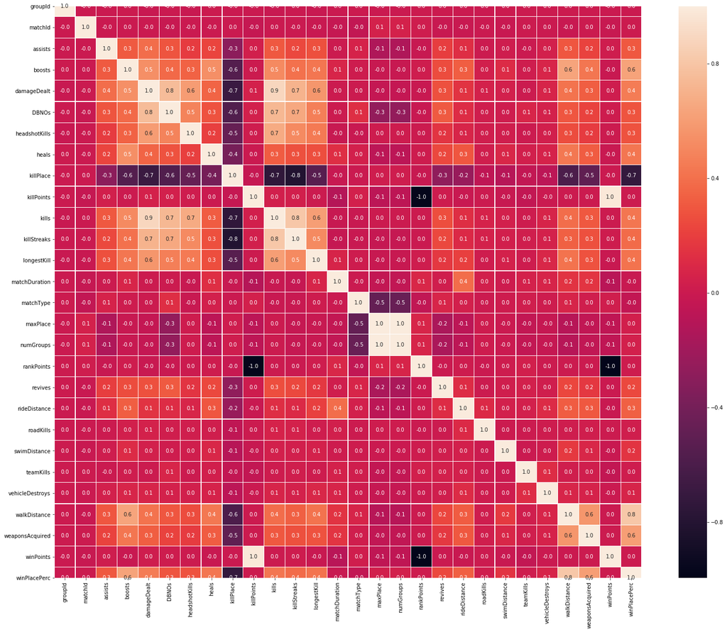

```python
fig, ax = plt.subplots(figsize=(25, 20))
sns.heatmap(train.corr(), annot=True, linewidths=0.2, fmt= '.1f', ax = ax)
plt.show()
```

La matrice de corrélation nous permet de déterminer quelles sont les variables les plus corrélées (positivement et négativement) à `winPlacePerc`.

Dans un modèle de prédiction en machine learning, la corrélation est bon indicateur afin de réduire le nombre de features dans le cas où elle est très importante. On remarque que la corrélation la plus forte est avec `walkDistance` (0.8), ce qui nous confirme avec l'hypothèse précédente qu'elle sera nuisible à notre modèle.

En revanche la corrélation ne préjuge pas de la pertinence d'une variable dans un modèle. On ne peut donc rien conclure sur les variables pour lesquelles la corrélation est nulle. Or, combiné à notre expérience de jeu ainsi qu'au graphique des *features importances*, nous pouvons supposer que supprimer les variables suivantes semblent pertinentes : `roadKills`, `teamKills`, `maxPlace`.

Nous voyons une corrélation forte entre les variables `kills`, `damageDealt`, `DBNOs` et `headshotKills`, ce qui s'explique par le fait que lorsqu'un joueur cause beaucoup de dommage à des ennemis, il a plus de chances de mettre à terre, voire de tuer. Malgré cette forte corrélation, nous décidons de ne pas supprimer ces variables car nous estimons que chacune apporte une information différente pour notre prédiction (par exemple, un bon joueur peut causer beaucoup de dégat sans avoir un nombre d'ennemis tués élevé).

Nous observons que `killPlace` a une corrélation négative et est également la feature la plus importante. Cela peut sembler contre-intuitif au premier abord car la variable `killPlace` représente le classement du joueur par rapport au nombre d'ennemis tués. Elle devrait alors avoir une corrélation positive avec `winPlacePerc`. L'explication est très simple : plus la valeur de `killPlace` est proche de 1, meilleur est le classement.

Nous remarquons une corrélation de -1 entre `rankPoints` et `winPoints`, et entre `rankPoints` et `killPoints`. En effet `rankPoints` est construit à partir de `winPoints`et `killPoints`. Il peut alors y avoir un soucis de colinéarité entre ces trois variables. On décide donc de supprimer `winPoints` et `killPoints`et de ne garder que `rankPoints`. Lorsque nous ne disposons pas de `rankPoints` pour un joueur, nous décidons de lui attribuer une valeur égale à la moyenne entre `winPoints` et `killPoints`.

```python
X_train['rankPoints'] = X_train.apply(lambda var : var['rankPoints'] if var["rankPoints"]>0 else ((var['winPoints']+var['killPoints'])/2), axis = 1)

labels_to_drop = ['roadKills', 'teamKills', 'maxPlace', 'winPoints', 'killPoints']
X_train = X_train.drop(labels_to_drop, axis = 1)
X_test = X_test.drop(labels_to_drop, axis = 1)
```

**Analyse des variables "non pertinentes"**

Dans cette partie nous souhaitons analyser des variables qui semblent peu pertinentes au premier abord pour la prédiction de `winPlacePerc`. Il s'agit de variables ayant une corrélation nulle et une importance faible, mais qui d'après notre expérience de jeu nous semblent importantes pour mener un joueur à la victoire.

`vehicleDestroys` : Par exemple, nous avons décidé de garder la variable `vehicleDestroys` car détruire un véhicule en mouvement demande une certaine maitrise du jeu. Vérifions sa relation avec la variable `winPlacePerc`.

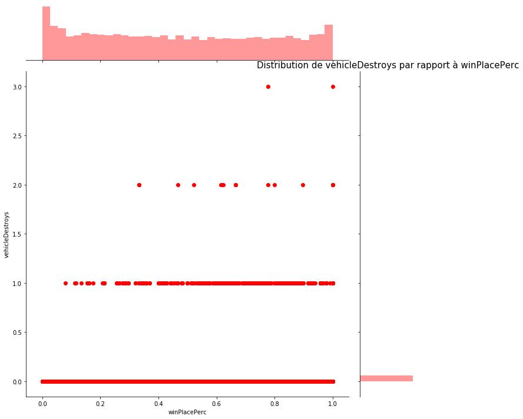

```python
plt.figure(figsize=(45,15))
sns.jointplot(y_train, X_train.vehicleDestroys, height=10, ratio=5, color="r")
plt.title('Distribution de vehicleDestroys par rapport à winPlacePerc', fontsize=15)
plt.show()
```

Ce graphique confirme nos dires : détruire un véhicule est rare et ne pénalise pas pour gagner, mais lorsque c'est fait les probabilités de gagner augmentent drastiquement.

`heals` : La consommation d'objets de soin permet une meilleure survivabilité dans le jeu. On peut imaginer qu'elle soit alors une variable importante dans la prédiction de la victoire.

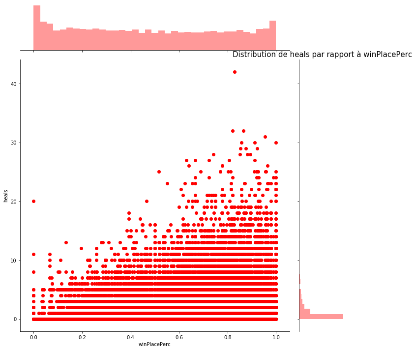

```python
plt.figure(figsize=(45,15))
sns.jointplot(y_train, X_train.heals, height=10, ratio=5, color="r")
plt.title('Distribution de heals par rapport à winPlacePerc', fontsize=15)
plt.show()
```

`boosts` : La consommation d'objets de type boost permet une meilleure régénération de la vie ainsi qu'une vitesse de course plus rapide et améliore également la survivabilité.

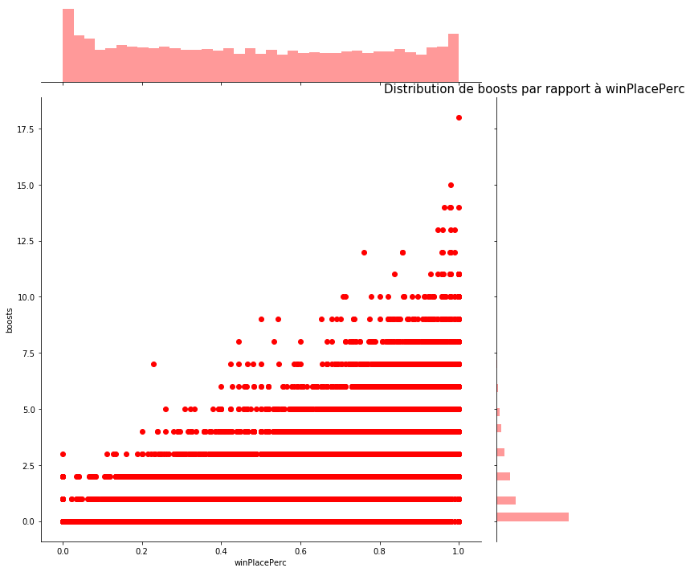

```python
plt.figure(figsize=(45,15))
sns.jointplot(y_train, X_train.boosts, height=10, ratio=5, color="r")
plt.title('Distribution de boosts par rapport à winPlacePerc', fontsize=15)
plt.show()
```

`swimDistance` : Certaines cartes dans le jeu nécessitent de nager afin de rester ou rejoindre la zone de sécurité. On peut alors penser que si un joueur nage plus qu'un autre, alors ses chances de survies seront meilleures.

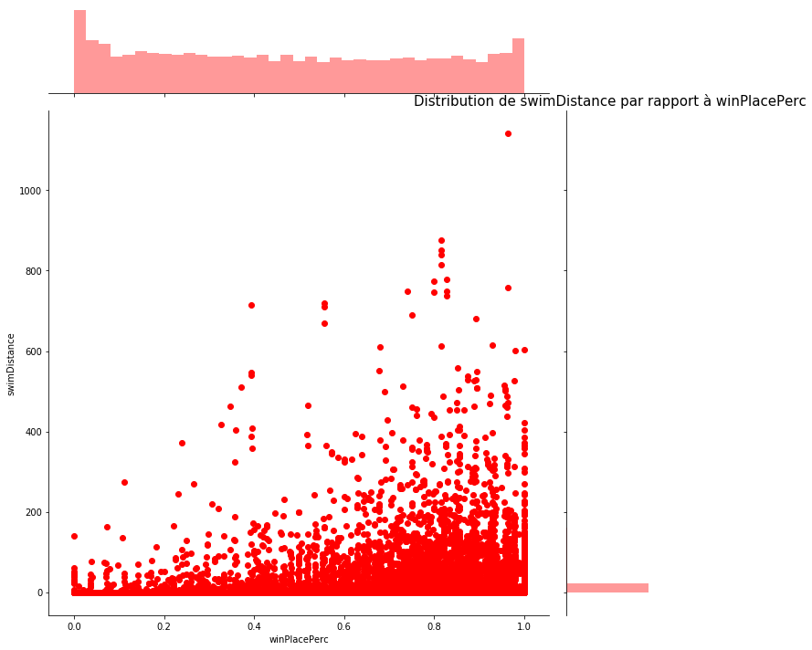

```python
plt.figure(figsize=(45,15))
sns.jointplot(y_train, X_train.swimDistance, height=10, ratio=5, color="r")
plt.title('Distribution de swimDistance par rapport à winPlacePerc', fontsize=15)
plt.show()
```

`rideDistance` : Dans le jeu, il est possible de trouver des véhicules et de les conduire. Avoir un véhicule permet une meilleure mobilité afin de rejoindre la zone de sécurité, et assure une meilleure survivabilité.

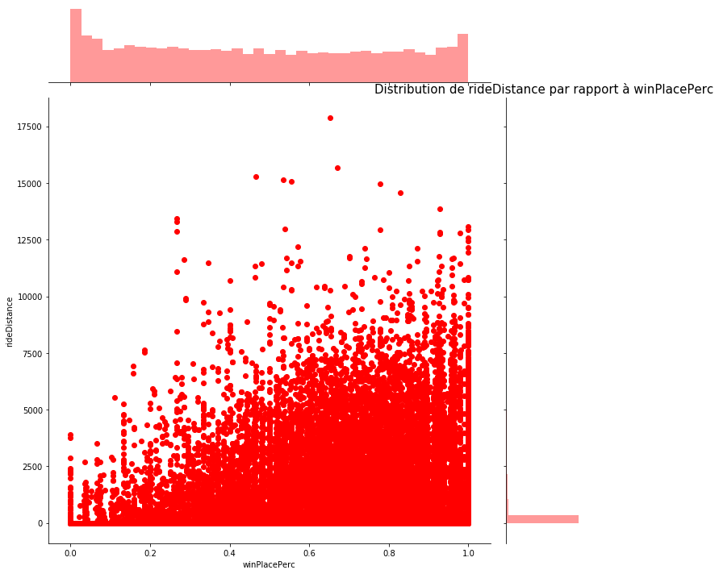

```python
plt.figure(figsize=(45,15))
sns.jointplot(y_train, X_train.rideDistance, height=10, ratio=5, color="r")
plt.title('Distribution de rideDistance par rapport à winPlacePerc', fontsize=15)
plt.show()
```

`matchType` : Comme expliqué précédemment, trois modes sont possibles dans le jeu : solo, duo et squad. Garder cette variable en tant que feature semble pertinent car d'après notre expérience de jeu, nous estimons que les features importantes ne seront pas les mêmes selon le mode.

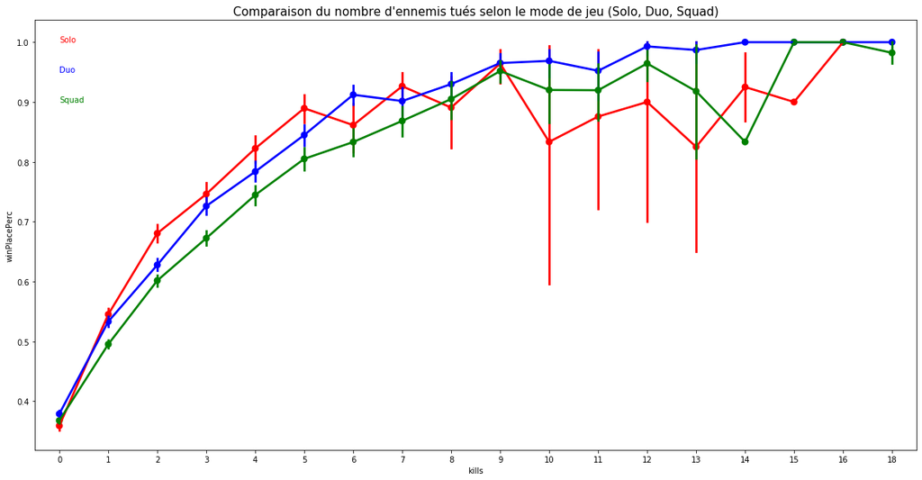

```python
plt.figure(figsize=(20,10))
sns.pointplot(X_train[X_train['matchType']==1].kills, y_train[(X_train['matchType']==1).index], color="r")
sns.pointplot(X_train[X_train['matchType']==0].kills, y_train[(X_train['matchType']==0).index], color="b")
sns.pointplot(X_train[X_train['matchType']==2].kills, y_train[(X_train['matchType']==2).index], color="g")
plt.text(0,1, 'Solo', color='r')
plt.text(0,0.95, 'Duo', color='b')
plt.text(0,0.90, 'Squad', color='g')
plt.title("Comparaison du nombre d'ennemis tués selon le mode de jeu (Solo, Duo, Squad)", fontsize=15)
plt.show()
```

On observe que le nombre d'ennemis tués dans une partie solo ou duo est relativement aussi significatif pour la prédiction du classement. En revanche, ce n'est pas le cas pour les parties en squad pour lesquelles, le nombre d'ennemis tués par joueur devient moins significatif. Il serait plus judicieux de regarder le nombre d'ennemis tués total par équipe pour le cas en duo et en squad.

Ce graphique nous conforte dans l'idée que l'importance des features sera bien différente selon le mode de la partie. Garder la variable `matchType` semble alors bien pertinent.

**Feature engineering**

Dans cette partie, nous allons créer des features supplémentaires qui nous semblent pertinents pour l'amélioration de la prédiction de notre modèle.

`tot_boosts_heals` : Cette variable correspond au nombre total de boosts et heals consommés par l'équipe du joueur. Cette variable nous semble pertinente car plus le nombre de boosts et heals consommés par une équipe est fort et plus l'équipe a une survivabilité importante.

`tot_assists` : Cette variable correspond au nombre total d'assistance de l'équipe du joueur.

`tot_DBNOs` : Cette variable correspond au nombre total de DBNO de l'équipe du joueur.

`tot_distance`: Cette variable correspond au nombre total de mètres parcourus par l'équipe en véhicule ou à la nage.

```python
X_train['tot_boosts_heals'] = X_train.groupby(['groupId'])['boosts'].transform(np.sum) + X_train.groupby(['groupId'])['heals'].transform(np.sum)
X_train['tot_assists'] = X_train.groupby(['groupId'])['assists'].transform(np.sum)
X_train['tot_DBNOs'] = X_train.groupby(['groupId'])['DBNOs'].transform(np.sum)
X_train['tot_distance'] = X_train.groupby(['groupId'])['swimDistance'].transform(np.sum) + X_train.groupby(['groupId'])['rideDistance'].transform(np.sum)

X_test['tot_boosts_heals'] = X_test.groupby(['groupId'])['boosts'].transform(np.sum) + X_test.groupby(['groupId'])['heals'].transform(np.sum)
X_test['tot_assists'] = X_test.groupby(['groupId'])['assists'].transform(np.sum)
X_test['tot_DBNOs'] = X_test.groupby(['groupId'])['DBNOs'].transform(np.sum)
X_test['tot_distance'] = X_test.groupby(['groupId'])['swimDistance'].transform(np.sum) + X_test.groupby(['groupId'])['rideDistance'].transform(np.sum)
```

`nb_players_in_team` : Cette variable correspond au nombre de coéquipiers dans l'équipe du joueur, en effet il se peut parfois qu'une équipe en squad ou en duo ne soit pas complète.

```python
X_train['nb_players_in_team'] = X_train.groupby(['groupId'])['kills'].transform('count')

X_test['nb_players_in_team'] = X_test.groupby(['groupId'])['kills'].transform('count')
```

`kill_rate` : Cette variable correspond au nombre d'ennemis tués par le joueur par rapport au nombre total d'ennemis tués par son équipe.

`damage_rate` : Cette variable correspond au nombre de dégâts causés par le joueur par rapport au nombre total de dégâts causés par son équipe.

Ces variables nous semblent pertinentes car elles démontrent l'homogéneité de l'équipe.

```python
X_train['kill_rate'] = X_train['kills'] / X_train.groupby(['groupId'])['kills'].transform(np.sum)
X_train['damage_rate'] = X_train['damageDealt'] / X_train.groupby(['groupId'])['damageDealt'].transform(np.sum)

X_test['kill_rate'] = X_test['kills'] / X_test.groupby(['groupId'])['kills'].transform(np.sum)
X_test['damage_rate'] = X_test['damageDealt'] / X_test.groupby(['groupId'])['damageDealt'].transform(np.sum)
```

`team_kill_rate` : Cette variable correspond au nombre total d'ennemis tués par l'équipe du joueur par rapport au nombre total d'ennemis tués dans la partie.

`team_damage_rate` : Cette variable correspond au nombre total de dégâts causés par l'équipe du joueur par rapport au nombre total de dégâts causés dans la partie.

Ces variables nous semblent pertinentes car elles démontrent la puissance de l'équipe.

```python
X_train['team_kill_rate'] = X_train.groupby(['groupId'])['kills'].transform(np.sum) / X_train.groupby(['matchId'])['kills'].transform(np.sum)
X_train['team_damage_rate'] = X_train.groupby(['groupId'])['damageDealt'].transform(np.sum) / X_train.groupby(['matchId'])['damageDealt'].transform(np.sum)

X_test['team_kill_rate'] = X_test.groupby(['groupId'])['kills'].transform(np.sum) / X_test.groupby(['matchId'])['kills'].transform(np.sum)
X_test['team_damage_rate'] = X_test.groupby(['groupId'])['damageDealt'].transform(np.sum) / X_test.groupby(['matchId'])['damageDealt'].transform(np.sum)
```

`importance_team` : Cette variable correspond au nombre total de coéquipiers dans l'équipe du joueur par rapport au nombre total dans la partie. Cette variable nous semble pertinente car une équipe qui n'est pas au complet par avec un désavantage.

```python
X_train['importance_team'] = X_train['nb_players_in_team'] / X_train.groupby(['matchId'])['kills'].transform('count')

X_test['importance_team'] = X_test['nb_players_in_team'] / X_test.groupby(['matchId'])['kills'].transform('count')
```

`headshot_rate` : Cette variable correspond au nombre total d'ennemis tués par une balle à la tête par rapport au nombre total d'ennemis tués par le joueur. Cette variable nous semble pertinente car elle représente la compétence de visée du joueur.

```python
X_train['headshot_rate'] = X_train['headshotKills'] / X_train['kills']

X_test['headshot_rate'] = X_test['headshotKills'] / X_test['kills']
```

```python
X_train = X_train.fillna(0)
X_test = X_test.fillna(0)

X_train = X_train.drop(['groupId'], axis = 1)
X_test = X_test.drop(['groupId'], axis = 1)
X_train.info()
```

```
<class 'pandas.core.frame.DataFrame'>
Int64Index: 62096 entries, 10 to 4446947
Data columns (total 31 columns):
matchId               62096 non-null int32
assists               62096 non-null int64
boosts                62096 non-null int64
damageDealt           62096 non-null float64
DBNOs                 62096 non-null int64
headshotKills         62096 non-null int64
heals                 62096 non-null int64
killPlace             62096 non-null int64
kills                 62096 non-null int64
killStreaks           62096 non-null int64
longestKill           62096 non-null float64
matchDuration         62096 non-null int64
matchType             62096 non-null int32
numGroups             62096 non-null int64
rankPoints            62096 non-null float64
revives               62096 non-null int64
rideDistance          62096 non-null float64
swimDistance          62096 non-null float64
vehicleDestroys       62096 non-null int64
weaponsAcquired       62096 non-null int64
tot_boosts_heals      62096 non-null int64
tot_assists           62096 non-null int64
tot_DBNOs             62096 non-null int64
tot_distance          62096 non-null float64
nb_players_in_team    62096 non-null int64
kill_rate             62096 non-null float64
damage_rate           62096 non-null float64
team_kill_rate        62096 non-null float64
team_damage_rate      62096 non-null float64
importance_team       62096 non-null float64
headshot_rate         62096 non-null float64
dtypes: float64(12), int32(2), int64(17)
memory usage: 17.2 MB
```

## Modèles de prédiction

Dans cette dernière partie, nous cherchons à comparer plusieurs algorithmes de machine learning. Nous commençons par vérifier que le travail effectué sur les features nous permet d'améliorer le score de la baseline. Puis, nous cherchons à améliorer notre prédiction en utilisant des algorithmes ensemblistes censés donner de meilleurs résultats.

**Arbre de régression**

```python
clf = tree.DecisionTreeRegressor(random_state = 42)
clf.fit(X_train, y_train)
sum_err_mae = 0
count = 0
for i in X_test['matchId'].unique():
    y_predict = clf.predict(X_test[X_test['matchId'] == i])
    sum_err_mae += metrics.mean_absolute_error(y_test[(X_test['matchId'] == i)], y_predict)
    count += 1

print('MAE : {}'.format(round(sum_err_mae/count,4)))
```

```
MAE : 0.1038
```

**Random Forest**

Le Random Forest est une méthode d'apprentissage ensembliste pour la classification ou la regression. L'algorithme effectue un apprentissage sur de multiples arbres de décision indépendants car entraînés sur des sous-ensembles de données différents (méthode de bagging). Enfin, il corrige l'overfitting qu'a tendance à créer un arbre de décision seul.

Les hyperparamètres les plus importants dans un Random Forest sont :

- `n_estimators` : nombre d'arbres dans la forêt
- `math_depth` : profondeur maximale d'un arbre
- `min_samples_leaf` : taille minimale d'échantillon dans une feuille
- `max_features`: nombre de features à considérer pour chaque arbre de la forêt
- `max_samples`: taille de l'échantillon prise pour chaque arbre de la forêt

```python
RF = RandomForestRegressor(n_jobs=-1, criterion= 'mae')
RF.fit(X_train, y_train)
sum_err_mae = 0
count = 0
for i in X_test['matchId'].unique():
    y_predict = RF.predict(X_test[X_test['matchId'] == i])
    sum_err_mae += metrics.mean_absolute_error(y_test[(X_test['matchId'] == i)], y_predict)
    count += 1

print('MAE : {}'.format(round(sum_err_mae/count,4)))
```

```
MAE : 0.078
```

Malgré un temps d'exécution plus important, le Random Forest diminue largement l'erreur de prédiction obtenue précédémment, nous passons d'un MAE égal à 10.38% à un MAE égal à 7.8%.

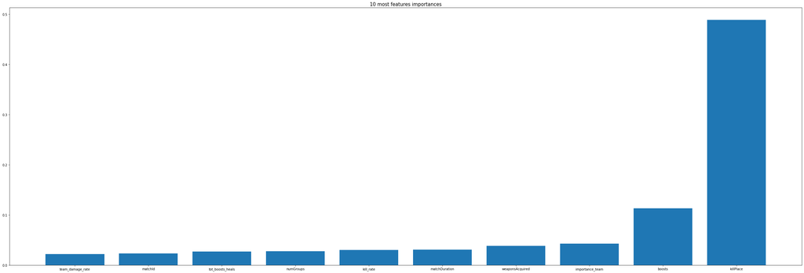

```python
labels = pd.DataFrame(X_test.columns)
feature_importances = pd.DataFrame(RF.feature_importances_)
df = pd.concat([labels, feature_importances], axis = 1)
df.columns = ['Features', 'Feature importances']
df.sort_values(by = ['Feature importances'], inplace = True)
plt.figure(figsize=(45,15))
plt.bar(df['Features'].tail(10), df['Feature importances'].tail(10))
plt.title('10 most features importances', fontsize=15)
plt.show()
```

Nous observons que la variable la plus significative pour la prédiction de la victoire d'un joueur est `killPlace`, ce qui nous semble logique car meilleur est son classement en nombre d'ennemis tués et meilleure sera la probabilité que le joueur soit bon et gagne.

En deuxième position, vient la variable `boosts`. Cela nous confirme dans l'idée que consommer du boosts est important car permet d'améliorer significativement la survivabilité du joueur.

Enfin, nous remarquons que certaines de nos variables créées sont présentes dans les 10 plus importantes features, ce qui confirme que notre feature engineering a été utile. Nos hypothèses ont donc été cohérentes avec le résultat du modèle.

Passons à l'optimisation des hyperparamètres du Random Forest en effectuant un grid search combiné à une cross-validation afin de trouver les paramètres les plus optimaux et de diminuer le risque d'overfitting.

```python
RF = RandomForestRegressor(n_jobs = -1, criterion= 'mae')
parameters = {'n_estimators': [10, 100],
              'min_samples_leaf': [1, 5, 10],
              'max_depth': [None, 1, 15],
              'max_features' : ['log2','sqrt']}

GSCV = GridSearchCV(estimator = RF,
                           param_grid = parameters,
                           scoring = 'neg_mean_absolute_error',
                           n_jobs = -1)

GSCV.fit(X_train, y_train)
RF_optim = GSCV.best_estimator_
sum_err_mae = 0
count = 0
for i in X_test['matchId'].unique():
    y_predict = RF_optim.predict(X_test[X_test['matchId'] == i])
    sum_err_mae += metrics.mean_absolute_error(y_test[(X_test['matchId'] == i)], y_predict)
    count += 1

print('MAE : {}'.format(round(sum_err_mae/count,4)))
```

Ayant du relancer tout le code, nous avons choisi de ne pas réexécuter l'optimisation des hyperparamètres du Random Forest car trop gourmande en puissance de calcul et en temps d'exécution (quelques heures...). En revanche, nous avions bien observé une baisse de l'erreur de manière significative.

Dans la dernière sous partie, nous souhaitons tester un LightGBM.

**LightGBM**

Le LightGBM est un gradient boosting framework utilisant des arbres de décisions entrainés. La principale différence avec un Random Forest est que chaque arbre de la forêt aléatoire n'est plus indépendant. En effet chaque arbre est construit en tenant compte de l'erreur de précision de l'arbre précédént en pondérant davantage les observations étant mal prédites.

Le LightGBM consisten en un gradient boosting rapide, distribué et performant. Il sépare l'arbre au niveau de la feuille contrairement à d'autres algorithmes qui évoluent par niveau. En évoluant ainsi, l'algorithme permet de réduire davantage la perte par rapport aux autres algorithmes de boosting et donc d'obtenir une bien meilleure précision. Contrairement au XGBoost, il est également plus rapide lorsque l'échantillon d'entraînement est assez conséquent, ce qui est notre cas ici.

Les hyperparamètres les plus importants dans un LightGBM sont :

- `num_leave`: Nombre maximal de feuilles pour les arbres entrainés. Le paramètre le plus important pour contrôler la complexité du modèle. Il doit être égale à `2^(max_depth)` pour obtenir le même nombre de feuilles qu'un algorithme qui opère par profondeur. Or l'algorithme serait alors beaucoup trop profond, ce qui induirait de l'over-fitting.
- `max_depth` : Limite la profondeur de manière explicite.
- `n_estimators` : Nombre d'arbres entrainés par boosting.
- `learning_rate` : Taux d'apprentissage du boosting. Un taux d'erreur faible combiné à un nombre d'itérations élevés améliore la précision`.

```python
LGBM = lgb.LGBMRegressor(objective='mae', n_jobs=-1, n_estimators=4000)
LGBM.fit(X_train, y_train, eval_metric='mae')
sum_err_mae = 0
count = 0
for i in X_test['matchId'].unique():
    y_predict = LGBM.predict(X_test[X_test['matchId'] == i])
    sum_err_mae += metrics.mean_absolute_error(y_test[(X_test['matchId'] == i)], y_predict)
    count += 1

print('MAE : {}'.format(round(sum_err_mae/count,4)))
```

```
MAE : 0.0667
```

Malgré le fait qu'il n'y ait pas eu de tunning des paramètres, on a pu baisser l'erreur de notre prédiction. On peut donc espérer une erreur encore plus faible avec tunning des paramètres. Le LightGBM semble donc meilleur tant en temps d'exécution qu'en précision.

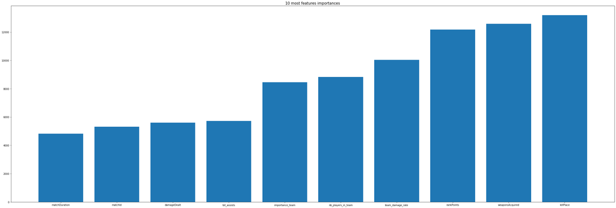

```python
labels = pd.DataFrame(X_test.columns)
feature_importances = pd.DataFrame(LGBM.feature_importances_)
df = pd.concat([labels, feature_importances], axis = 1)
df.columns = ['Features', 'Feature importances']
df.sort_values(by = ['Feature importances'], inplace = True)
plt.figure(figsize=(45,15))
plt.bar(df['Features'].tail(10), df['Feature importances'].tail(10))
plt.title('10 most features importances', fontsize=15)
plt.show()
```

Les features les plus importantes du modèle sont sensiblement différentes (par exemple, `boosts` n'en fait plus partie). On observe que les features portant sur des statistiques d'équipes sont plus importantes dans ce modèle par rapport au Random Forest. En effet, il est plus facile de prévoire le classement d'un joueur quand il joue en solo par rapport à en équipe. Donc, par construction le LightGBM mettra plus de pondération sur les joueurs en équipe (d'autant plus qu'ils sont majoritaires dans l'échantillon), ce qui explique l'importance des features communes.

Il nous semble donc plus pertinent d'utilier un LightGBM pour notre prédiction, car la plupart des parties du jeu PUBG sont jouées en équipes. Néanmoins, l'un des plus gros défauts du LightGBM est que son tunning est difficile.